# 睡眠 × 学习/工作/娱乐：日志数据的统计关系（单位已归一化）

# 1 0. 读者说明（尽量“懂一点统计”的普通大众能看懂）

这份报告只讨论**相关/统计关系**，不做“睡眠一定导致××”这种因果结论。

我们会反复用到一个很简单的线性模型（你可以把它理解成“带交互项的回归/方差分析”）：

- **同日**：`Y_z ~ sleep_z * week_part`
- **次日（next-day）**：`Y_next_z ~ sleep_z * week_part`

其中：

- `Y_z`：某类标签在当天的“归一化时间单位”（为了公开展示隐藏具体分钟数）
- `sleep_z`：当天“睡觉/补觉（且不含‘准备’）”的归一化指标（z-score）
- `week_part`：周中 vs 周末
- `*` 表示会同时估计：
  1. `sleep_z` 的主效应（总体上睡眠和 Y 的关系）
  2. `week_part` 的主效应（周末 vs 周中总体均值差）
  3. **交互作用** `sleep_z:week_part`（周末和周中“睡眠—Y 的关系”是否不一样）

> **交互作用显著**的意思是：两组（周中/周末）的“关系形式”或“均值差异随 sleep 改变的方式”不一样。  
> 它**不等于**“周末一定更高/更低”。要看模型预测的均值（我们会给出一个小表格）。

显著性报告格式（每个效应都会给）：

- `F(df1, df2) = ... , p = ... , partial η² = ...`
- `partial η²`（偏 η²）是常用效应量：越大表示该效应解释的变异比例越高（在控制残差后）。

# 2 1. 睡眠与“次日学习/工作/心智整理”的关系（重点）

我们先看最直观的问题：**睡觉/补觉多一些，第二天的学习/工作/心智整理是否更容易出现？这种关系在周中与周末是否不同？**

## 2.1 1.1 Next-day Study

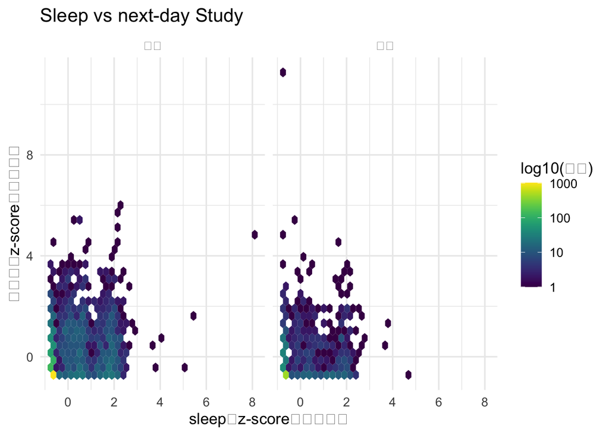

Figure 1. Sleep vs next-day Study（分周中/周末两列）。横轴：sleep（z-score，归一化）。纵轴：next-day Study（z-score，归一化）。颜色：hexbin 密度（log10 计数）。

```r
y <- "study_next_z"
mod <- lm(as.formula(paste0(y, " ~ sleep_z * week_part")), data = daily)
print(plot_hex_facet(daily, y, "Sleep vs next-day Study"))
```

```r
tbl <- anova_table_with_eta(mod)
kable(tbl, digits = 3, caption = "ANOVA（F 检验）与效应量（partial η²）：next-day Study")
```

ANOVA（F 检验）与效应量（partial η²）：next-day Study

| term | df1 | df2 | F | p | eta_p2 | p_fmt | F_fmt | eta_fmt |
| --- | --- | --- | --- | --- | --- | --- | --- | --- |
| sleep_z | 1 | 3696 | 455.676 | 0 | 0.110 | 1.94e-95*** | F(1,3696)=455.68 | ηp²=0.110 |
| week_part | 1 | 3696 | 16.598 | 0 | 0.004 | 4.72e-05*** | F(1,3696)=16.60 | ηp²=0.004 |
| sleep_z:week_part | 1 | 3696 | 16.429 | 0 | 0.004 | 5.15e-05*** | F(1,3696)=16.43 | ηp²=0.004 |

```r
kable(pred_table_3points(mod), digits = 3, caption = "模型预测均值（示意：sleep=-1/0/+1 SD）")
```

模型预测均值（示意：sleep=-1/0/+1 SD）

| sleep_level | 周中 | 周末 |
| --- | --- | --- |
| 低（-1SD） | -0.329 | -0.330 |
| 中（均值） | 0.040 | -0.101 |
| 高（+1SD） | 0.408 | 0.127 |

```r
kable(tidy_star(mod), digits = 3,
      caption = paste0("回归系数（含方向）：", y, " ~ sleep_z * week_part"))
```

回归系数（含方向）：study_next_z ~ sleep_z * week_part

| term | estimate | std.error | statistic | p.value | sig | direction |
| --- | --- | --- | --- | --- | --- | --- |
| (Intercept) | 0.040 | 0.018 | 2.162 | 0.031 | * |  |
| sleep_z | 0.368 | 0.018 | 20.232 | 0.000 | *** | 正向 |
| week_part周末 | -0.141 | 0.034 | -4.116 | 0.000 | *** | 负向 |
| sleep_z:week_part周末 | -0.140 | 0.034 | -4.053 | 0.000 | *** | 负向 |

```r
kable(simple_slopes_binary(mod, xname = "sleep_z", by = "week_part"), digits = 3,
      caption = paste0("简单斜率（按周中/周末）：sleep_z → ", y))
```

简单斜率（按周中/周末）：sleep_z → study_next_z

| group | slope | std.error | statistic | p.value | sig | direction |
| --- | --- | --- | --- | --- | --- | --- |
| 周中 | 0.368 | 0.018 | 20.232 | 0 | *** | 更多→更高 |
| 周末 | 0.228 | 0.029 | 7.802 | 0 | *** | 更多→更高 |

```r
kable(slope_diff_binary(mod, xname = "sleep_z", by = "week_part"), digits = 3,
      caption = paste0("斜率差（周末-周中）：sleep_z → ", y))
```

斜率差（周末-周中）：sleep_z → study_next_z

| contrast | slope_diff | std.error | statistic | p.value | sig | direction |
| --- | --- | --- | --- | --- | --- | --- |
| 周末 - 周中 | -0.14 | 0.034 | -4.053 | 0 | *** | 周末斜率更小 |

```r
cat_slope_summary(mod, xname = "sleep_z", yname = y, by = "week_part")
```

```
##
## - **方向（简单斜率）**：在 week_part=周中 时，sleep_z↑ → study_next_z 更高（斜率=0.368, p=2.07e-86）；在 week_part=周末 时，sleep_z↑ → study_next_z 更高（斜率=0.228, p=7.87e-15）。
```

```r
# 文字描述（不做过度推理，只解释统计含义）
int_row <- tbl %>% filter(term == "sleep_z:week_part")
main_sleep <- tbl %>% filter(term == "sleep_z")
main_week  <- tbl %>% filter(term == "week_part")

cat(paste0(
  "- **睡眠主效应**：", main_sleep$F_fmt, ", p=", main_sleep$p_fmt, ", ", main_sleep$eta_fmt, "。\n",
  "- **周末主效应**（在 sleep=均值处的整体差异）：", main_week$F_fmt, ", p=", main_week$p_fmt, ", ", main_week$eta_fmt, "。\n",
  "- **交互作用**（周末与周中“睡眠—Study 关系”是否不同）：", int_row$F_fmt, ", p=", int_row$p_fmt, ", ", int_row$eta_fmt, "。\n\n",
  "解读要点：交互项显著只说明两列（周中/周末）的关系形式不同；并不自动推出“周末一定更高/更低”。需要结合上面的预测均值表来判断差异是发生在低睡眠、中睡眠还是高睡眠水平。"
))
```

```
## - **睡眠主效应**：F(1,3696)=455.68, p=1.94e-95***, ηp²=0.110。
## - **周末主效应**（在 sleep=均值处的整体差异）：F(1,3696)=16.60, p=4.72e-05***, ηp²=0.004。
## - **交互作用**（周末与周中“睡眠—Study 关系”是否不同）：F(1,3696)=16.43, p=5.15e-05***, ηp²=0.004。
##
## 解读要点：交互项显著只说明两列（周中/周末）的关系形式不同；并不自动推出“周末一定更高/更低”。需要结合上面的预测均值表来判断差异是发生在低睡眠、中睡眠还是高睡眠水平。
```

## 2.2 1.2 Next-day Work

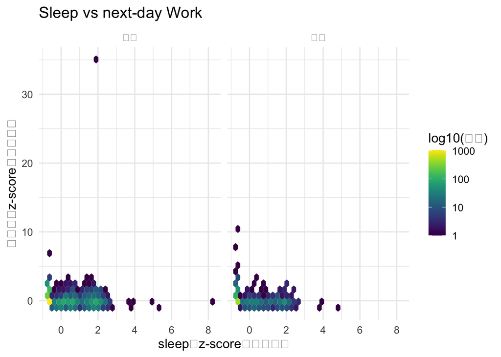

Figure 2. Sleep vs next-day Work（分周中/周末两列）。横轴：sleep（z-score，归一化）。纵轴：next-day Work（z-score，归一化）。颜色：hexbin 密度（log10 计数）。

```r
y <- "work_next_z"
mod <- lm(as.formula(paste0(y, " ~ sleep_z * week_part")), data = daily)
print(plot_hex_facet(daily, y, "Sleep vs next-day Work"))
```

```r
tbl <- anova_table_with_eta(mod)
kable(tbl, digits = 3, caption = "ANOVA（F 检验）与效应量（partial η²）：next-day Work")
```

ANOVA（F 检验）与效应量（partial η²）：next-day Work

| term | df1 | df2 | F | p | eta_p2 | p_fmt | F_fmt | eta_fmt |
| --- | --- | --- | --- | --- | --- | --- | --- | --- |
| sleep_z | 1 | 3696 | 24.878 | 0.000 | 0.007 | 6.39e-07*** | F(1,3696)=24.88 | ηp²=0.007 |
| week_part | 1 | 3696 | 4.056 | 0.044 | 0.001 | 0.044* | F(1,3696)=4.06 | ηp²=0.001 |
| sleep_z:week_part | 1 | 3696 | 3.795 | 0.051 | 0.001 | 0.051 | F(1,3696)=3.79 | ηp²=0.001 |

```r
kable(pred_table_3points(mod), digits = 3, caption = "模型预测均值（示意：sleep=-1/0/+1 SD）")
```

模型预测均值（示意：sleep=-1/0/+1 SD）

| sleep_level | 周中 | 周末 |
| --- | --- | --- |
| 低（-1SD） | 0.083 | 0.080 |
| 中（均值） | 0.021 | -0.053 |
| 高（+1SD） | -0.041 | -0.186 |

```r
kable(tidy_star(mod), digits = 3,
      caption = paste0("回归系数（含方向）：", y, " ~ sleep_z * week_part"))
```

回归系数（含方向）：work_next_z ~ sleep_z * week_part

| term | estimate | std.error | statistic | p.value | sig | direction |
| --- | --- | --- | --- | --- | --- | --- |
| (Intercept) | 0.021 | 0.019 | 1.069 | 0.285 |  |  |
| sleep_z | -0.062 | 0.019 | -3.226 | 0.001 | ** | 负向 |
| week_part周末 | -0.074 | 0.036 | -2.034 | 0.042 | * | 负向 |
| sleep_z:week_part周末 | -0.071 | 0.037 | -1.948 | 0.051 |  | 负向 |

```r
kable(simple_slopes_binary(mod, xname = "sleep_z", by = "week_part"), digits = 3,
      caption = paste0("简单斜率（按周中/周末）：sleep_z → ", y))
```

简单斜率（按周中/周末）：sleep_z → work_next_z

| group | slope | std.error | statistic | p.value | sig | direction |
| --- | --- | --- | --- | --- | --- | --- |
| 周中 | -0.062 | 0.019 | -3.226 | 0.001 | ** | 更多→更低 |
| 周末 | -0.133 | 0.031 | -4.298 | 0.000 | *** | 更多→更低 |

```r
kable(slope_diff_binary(mod, xname = "sleep_z", by = "week_part"), digits = 3,
      caption = paste0("斜率差（周末-周中）：sleep_z → ", y))
```

斜率差（周末-周中）：sleep_z → work_next_z

| contrast | slope_diff | std.error | statistic | p.value | sig | direction |
| --- | --- | --- | --- | --- | --- | --- |
| 周末 - 周中 | -0.071 | 0.037 | -1.948 | 0.051 |  | 周末斜率更小 |

```r
cat_slope_summary(mod, xname = "sleep_z", yname = y, by = "week_part")
```

```
##
## - **方向（简单斜率）**：在 week_part=周中 时，sleep_z↑ → work_next_z 更低（斜率=-0.0622, p=0.001）；在 week_part=周末 时，sleep_z↑ → work_next_z 更低（斜率=-0.133, p=1.76e-05）。
```

```r
int_row <- tbl %>% filter(term == "sleep_z:week_part")
main_sleep <- tbl %>% filter(term == "sleep_z")
main_week  <- tbl %>% filter(term == "week_part")

cat(paste0(
  "- 睡眠主效应：", main_sleep$F_fmt, ", p=", main_sleep$p_fmt, ", ", main_sleep$eta_fmt, "。\n",
  "- 周末主效应：", main_week$F_fmt, ", p=", main_week$p_fmt, ", ", main_week$eta_fmt, "。\n",
  "- 交互作用：", int_row$F_fmt, ", p=", int_row$p_fmt, ", ", int_row$eta_fmt, "。\n"
))
```

```
## - 睡眠主效应：F(1,3696)=24.88, p=6.39e-07***, ηp²=0.007。
## - 周末主效应：F(1,3696)=4.06, p=0.044*, ηp²=0.001。
## - 交互作用：F(1,3696)=3.79, p=0.051, ηp²=0.001。
```

## 2.3 1.3 Next-day Mind_Clearing

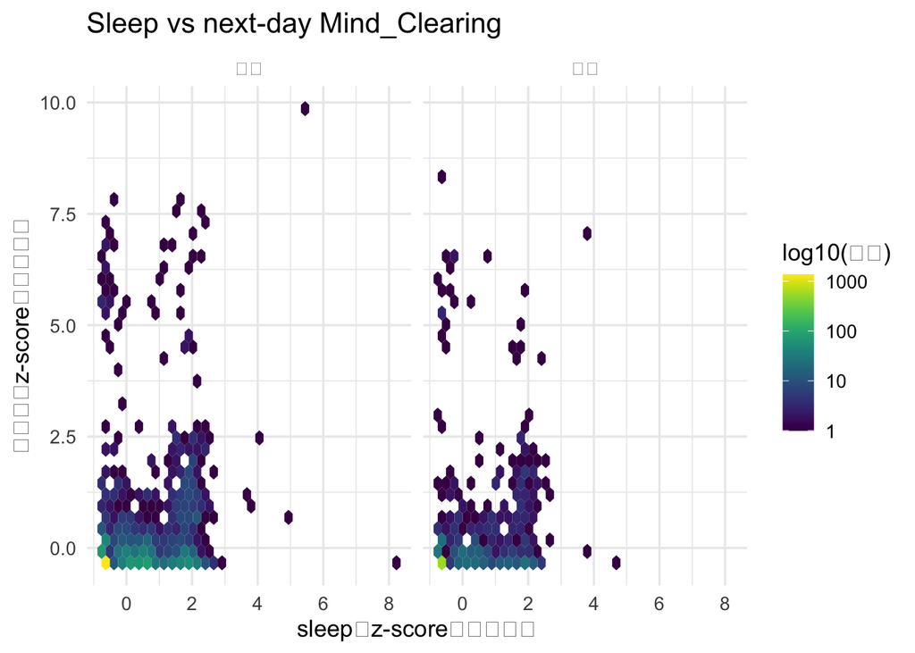

Figure 3. Sleep vs next-day Mind_Clearing（分周中/周末两列）。横轴：sleep（z-score，归一化）。纵轴：next-day Mind_Clearing（z-score，归一化）。颜色：hexbin 密度（log10 计数）。

```r
y <- "mind_next_z"
mod <- lm(as.formula(paste0(y, " ~ sleep_z * week_part")), data = daily)
print(plot_hex_facet(daily, y, "Sleep vs next-day Mind_Clearing"))
```

```r
tbl <- anova_table_with_eta(mod)
kable(tbl, digits = 3, caption = "ANOVA（F 检验）与效应量（partial η²）：next-day Mind_Clearing")
```

ANOVA（F 检验）与效应量（partial η²）：next-day Mind_Clearing

| term | df1 | df2 | F | p | eta_p2 | p_fmt | F_fmt | eta_fmt |
| --- | --- | --- | --- | --- | --- | --- | --- | --- |
| sleep_z | 1 | 3696 | 379.069 | 0.000 | 0.093 | 1.87e-80*** | F(1,3696)=379.07 | ηp²=0.093 |
| week_part | 1 | 3696 | 1.010 | 0.315 | 0.000 | 0.315 | F(1,3696)=1.01 | ηp²=0.000 |
| sleep_z:week_part | 1 | 3696 | 0.088 | 0.767 | 0.000 | 0.767 | F(1,3696)=0.09 | ηp²=0.000 |

```r
kable(pred_table_3points(mod), digits = 3, caption = "模型预测均值（示意：sleep=-1/0/+1 SD）")
```

模型预测均值（示意：sleep=-1/0/+1 SD）

| sleep_level | 周中 | 周末 |
| --- | --- | --- |
| 低（-1SD） | -0.318 | -0.273 |
| 中（均值） | -0.010 | 0.025 |
| 高（+1SD） | 0.298 | 0.322 |

```r
kable(tidy_star(mod), digits = 3,
      caption = paste0("回归系数（含方向）：", y, " ~ sleep_z * week_part"))
```

回归系数（含方向）：mind_next_z ~ sleep_z * week_part

| term | estimate | std.error | statistic | p.value | sig | direction |
| --- | --- | --- | --- | --- | --- | --- |
| (Intercept) | -0.010 | 0.019 | -0.538 | 0.591 |  |  |
| sleep_z | 0.308 | 0.018 | 16.701 | 0.000 | *** | 正向 |
| week_part周末 | 0.035 | 0.035 | 1.002 | 0.317 |  | 正向 |
| sleep_z:week_part周末 | -0.010 | 0.035 | -0.296 | 0.767 |  | 负向 |

```r
kable(simple_slopes_binary(mod, xname = "sleep_z", by = "week_part"), digits = 3,
      caption = paste0("简单斜率（按周中/周末）：sleep_z → ", y))
```

简单斜率（按周中/周末）：sleep_z → mind_next_z

| group | slope | std.error | statistic | p.value | sig | direction |
| --- | --- | --- | --- | --- | --- | --- |
| 周中 | 0.308 | 0.018 | 16.701 | 0 | *** | 更多→更高 |
| 周末 | 0.298 | 0.030 | 10.030 | 0 | *** | 更多→更高 |

```r
kable(slope_diff_binary(mod, xname = "sleep_z", by = "week_part"), digits = 3,
      caption = paste0("斜率差（周末-周中）：sleep_z → ", y))
```

斜率差（周末-周中）：sleep_z → mind_next_z

| contrast | slope_diff | std.error | statistic | p.value | sig | direction |
| --- | --- | --- | --- | --- | --- | --- |
| 周末 - 周中 | -0.01 | 0.035 | -0.296 | 0.767 |  | 周末斜率更小 |

```r
cat_slope_summary(mod, xname = "sleep_z", yname = y, by = "week_part")
```

```
##
## - **方向（简单斜率）**：在 week_part=周中 时，sleep_z↑ → mind_next_z 更高（斜率=0.308, p=2.01e-60）；在 week_part=周末 时，sleep_z↑ → mind_next_z 更高（斜率=0.298, p=2.22e-23）。
```

```r
int_row <- tbl %>% filter(term == "sleep_z:week_part")
main_sleep <- tbl %>% filter(term == "sleep_z")
main_week  <- tbl %>% filter(term == "week_part")

cat(paste0(
  "- 睡眠主效应：", main_sleep$F_fmt, ", p=", main_sleep$p_fmt, ", ", main_sleep$eta_fmt, "。\n",
  "- 周末主效应：", main_week$F_fmt, ", p=", main_week$p_fmt, ", ", main_week$eta_fmt, "。\n",
  "- 交互作用：", int_row$F_fmt, ", p=", int_row$p_fmt, ", ", int_row$eta_fmt, "。\n"
))
```

```
## - 睡眠主效应：F(1,3696)=379.07, p=1.87e-80***, ηp²=0.093。
## - 周末主效应：F(1,3696)=1.01, p=0.315, ηp²=0.000。
## - 交互作用：F(1,3696)=0.09, p=0.767, ηp²=0.000。
```

## 2.4 1.4 反向：学习/工作/心智整理 → 次日睡眠

把箭头反过来：今天学习/工作/心智整理多一些，是否会在**第二天睡眠**里体现出某种统计关系？（仍按周中/周末分面；同样只讨论相关，不做因果结论。）

### 2.4.1 1.4.1 Study → next-day Sleep

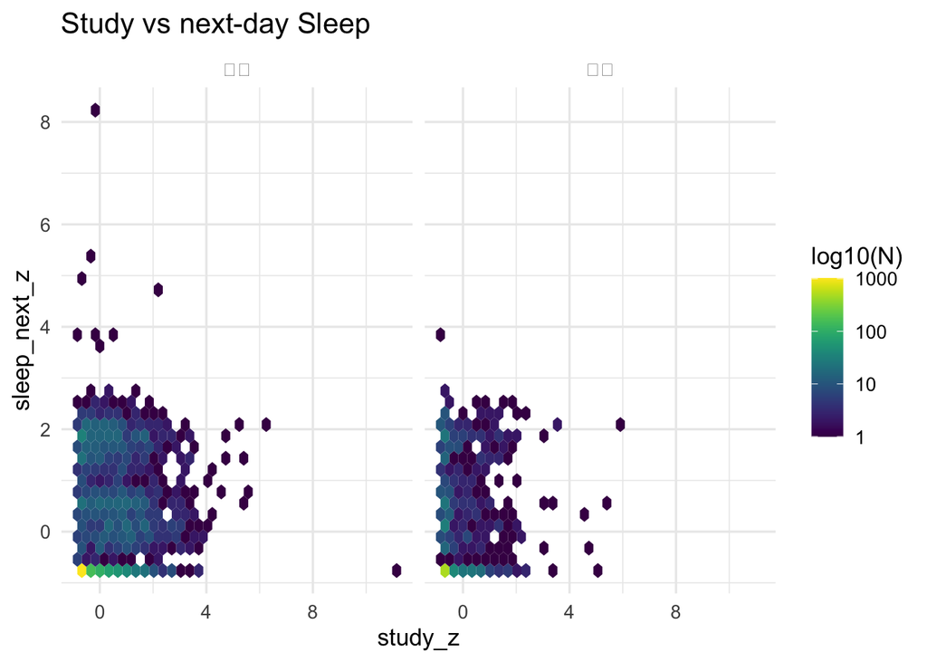

Figure. Study vs next-day Sleep（分周中/周末两列）。横轴：Study（z-score，归一化）。纵轴：next-day Sleep（z-score，归一化）。颜色：hexbin 密度（log10 计数）。

```
##
## - **方向（简单斜率）**：在 week_part=周中 时，study_z↑ → sleep_next_z 更高（斜率=0.306, p=1.98e-64）；在 week_part=周末 时，study_z↑ → sleep_next_z 更高（斜率=0.296, p=8.25e-16）。
```

```r
x <- "study_z"
y <- "sleep_next_z"
if (all(c(x, y) %in% names(daily))) {
  mod <- lm(as.formula(paste0(y, " ~ ", x, " * week_part")), data = daily)
  print(plot_hex_facet_xy(daily, x, y, "Study vs next-day Sleep"))
  kable(anova_table_with_eta(mod), digits = 3, caption = "ANOVA（F）与 partial η²：Study → next-day Sleep")
  kable(pred_table_3points_xy(mod, x), digits = 3, caption = "模型预测均值（示意：Study=-1/0/+1 SD）")

kable(tidy_star(mod), digits = 3,
      caption = paste0("回归系数（含方向）：", x, " → ", y))
kable(simple_slopes_binary(mod, xname = x, by = "week_part"), digits = 3,
      caption = paste0("简单斜率（按周中/周末）：", x, " → ", y))
kable(slope_diff_binary(mod, xname = x, by = "week_part"), digits = 3,
      caption = paste0("斜率差（周末-周中）：", x, " → ", y))
cat_slope_summary(mod, xname = x, yname = y, by = "week_part")

}
```

### 2.4.2 1.4.2 Work → next-day Sleep

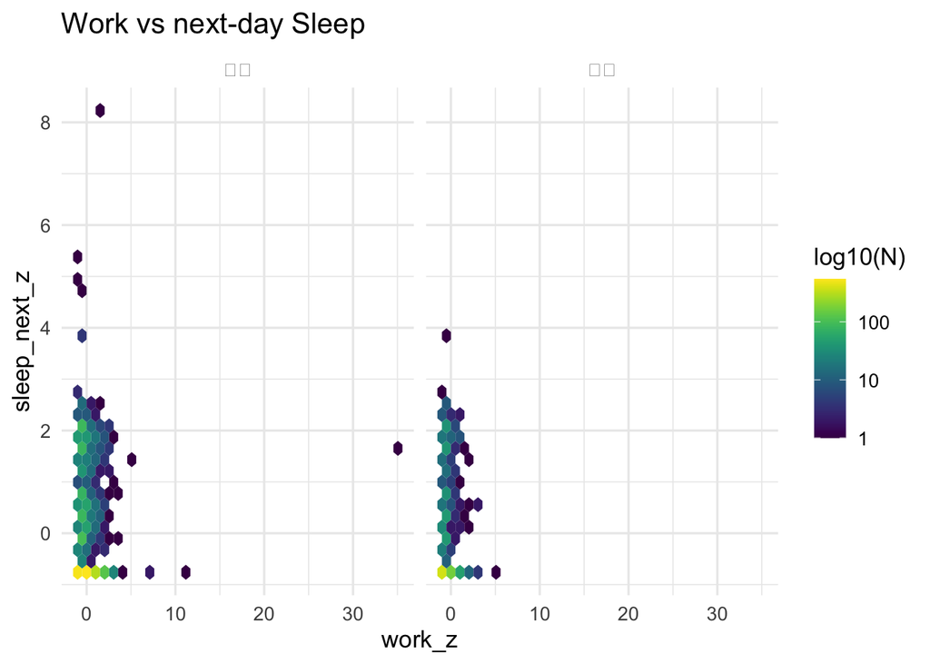

Figure. Work vs next-day Sleep（分周中/周末两列）。横轴：Work（z-score，归一化）。纵轴：next-day Sleep（z-score，归一化）。颜色：hexbin 密度（log10 计数）。

```
##
## - **方向（简单斜率）**：在 week_part=周中 时，work_z↑ → sleep_next_z 更低（斜率=-0.0767, p=1.28e-05）；在 week_part=周末 时，work_z↑ → sleep_next_z 更低（斜率=-0.114, p=0.029）。
```

```r
x <- "work_z"
y <- "sleep_next_z"
if (all(c(x, y) %in% names(daily))) {
  mod <- lm(as.formula(paste0(y, " ~ ", x, " * week_part")), data = daily)
  print(plot_hex_facet_xy(daily, x, y, "Work vs next-day Sleep"))
  kable(anova_table_with_eta(mod), digits = 3, caption = "ANOVA（F）与 partial η²：Work → next-day Sleep")
  kable(pred_table_3points_xy(mod, x), digits = 3, caption = "模型预测均值（示意：Work=-1/0/+1 SD）")

kable(tidy_star(mod), digits = 3,
      caption = paste0("回归系数（含方向）：", x, " → ", y))
kable(simple_slopes_binary(mod, xname = x, by = "week_part"), digits = 3,
      caption = paste0("简单斜率（按周中/周末）：", x, " → ", y))
kable(slope_diff_binary(mod, xname = x, by = "week_part"), digits = 3,
      caption = paste0("斜率差（周末-周中）：", x, " → ", y))
cat_slope_summary(mod, xname = x, yname = y, by = "week_part")

}
```

### 2.4.3 1.4.3 Mind_Clearing → next-day Sleep

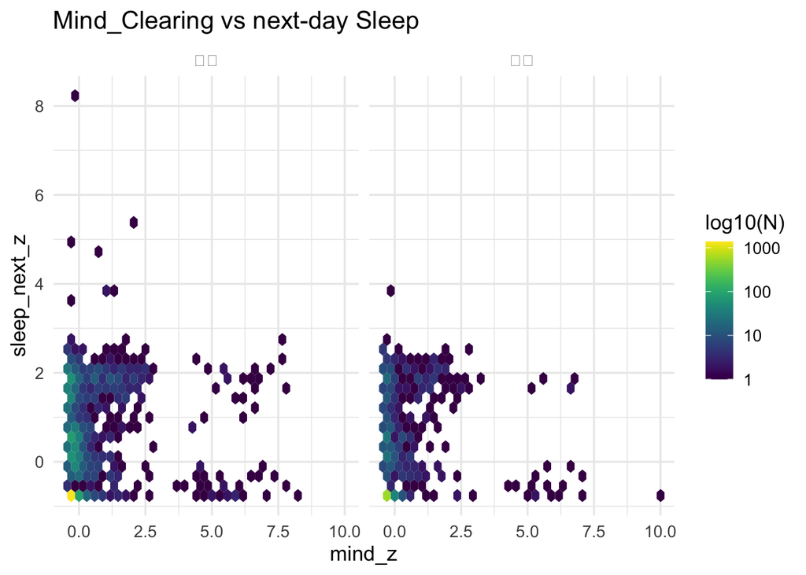

Figure. Mind_Clearing vs next-day Sleep（分周中/周末两列）。横轴：Mind_Clearing（z-score，归一化）。纵轴：next-day Sleep（z-score，归一化）。颜色：hexbin 密度（log10 计数）。

```
##
## - **方向（简单斜率）**：在 week_part=周中 时，mind_z↑ → sleep_next_z 更高（斜率=0.299, p=2.20e-54）；在 week_part=周末 时，mind_z↑ → sleep_next_z 更高（斜率=0.232, p=7.31e-16）。
```

```r
x <- "mind_z"
y <- "sleep_next_z"
if (all(c(x, y) %in% names(daily))) {
  mod <- lm(as.formula(paste0(y, " ~ ", x, " * week_part")), data = daily)
  print(plot_hex_facet_xy(daily, x, y, "Mind_Clearing vs next-day Sleep"))
  kable(anova_table_with_eta(mod), digits = 3, caption = "ANOVA（F）与 partial η²：Mind_Clearing → next-day Sleep")
  kable(pred_table_3points_xy(mod, x), digits = 3, caption = "模型预测均值（示意：Mind=-1/0/+1 SD）")

kable(tidy_star(mod), digits = 3,
      caption = paste0("回归系数（含方向）：", x, " → ", y))
kable(simple_slopes_binary(mod, xname = x, by = "week_part"), digits = 3,
      caption = paste0("简单斜率（按周中/周末）：", x, " → ", y))
kable(slope_diff_binary(mod, xname = x, by = "week_part"), digits = 3,
      caption = paste0("斜率差（周末-周中）：", x, " → ", y))
cat_slope_summary(mod, xname = x, yname = y, by = "week_part")

}
```

# 3 2. 睡眠与“当日学习/工作/心智整理”的关系（补充）

同样的模型，但因变量换成当日指标（`*_z`）。

## 3.1 2.1 Same-day Study

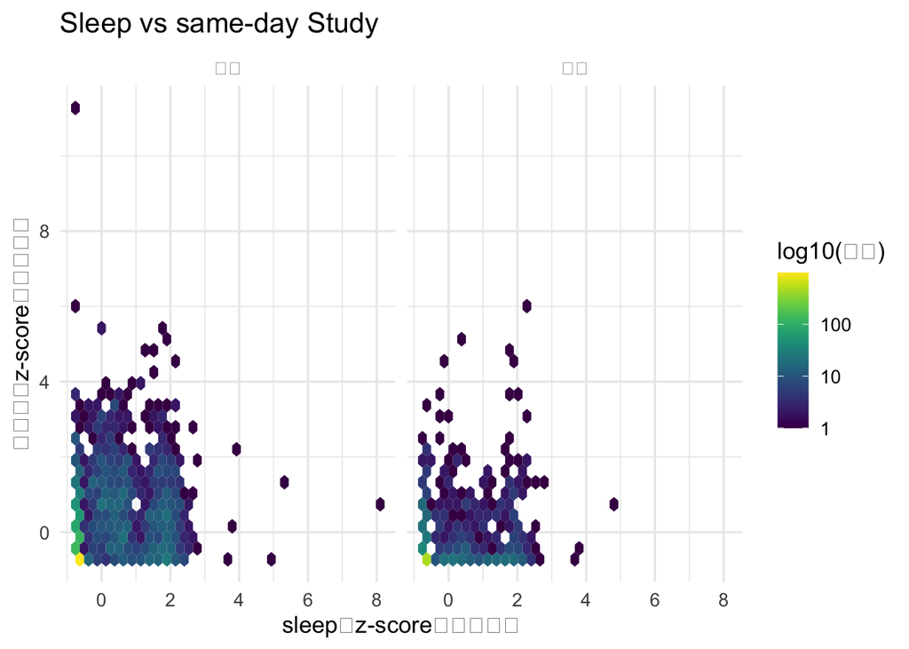

Figure 4. Sleep vs same-day Study（分周中/周末两列）。横轴：sleep（z-score，归一化）。纵轴：Study（z-score，归一化）。颜色：hexbin 密度（log10 计数）。

```r
y <- "study_z"
mod <- lm(as.formula(paste0(y, " ~ sleep_z * week_part")), data = daily)
print(plot_hex_facet(daily, y, "Sleep vs same-day Study"))
```

```r
kable(anova_table_with_eta(mod), digits = 3, caption = "ANOVA（F）与 partial η²：same-day Study")
```

ANOVA（F）与 partial η²：same-day Study

| term | df1 | df2 | F | p | eta_p2 | p_fmt | F_fmt | eta_fmt |
| --- | --- | --- | --- | --- | --- | --- | --- | --- |
| sleep_z | 1 | 3696 | 388.448 | 0 | 0.095 | 2.64e-82*** | F(1,3696)=388.45 | ηp²=0.095 |
| week_part | 1 | 3696 | 114.068 | 0 | 0.030 | 3.03e-26*** | F(1,3696)=114.07 | ηp²=0.030 |
| sleep_z:week_part | 1 | 3696 | 15.122 | 0 | 0.004 | 1.03e-04*** | F(1,3696)=15.12 | ηp²=0.004 |

```r
kable(tidy_star(mod), digits = 3,
      caption = paste0("回归系数（含方向）：", y, " ~ sleep_z * week_part"))
```

回归系数（含方向）：study_z ~ sleep_z * week_part

| term | estimate | std.error | statistic | p.value | sig | direction |
| --- | --- | --- | --- | --- | --- | --- |
| (Intercept) | 0.104 | 0.018 | 5.692 | 0 | *** |  |
| sleep_z | 0.339 | 0.018 | 18.695 | 0 | *** | 正向 |
| week_part周末 | -0.366 | 0.034 | -10.720 | 0 | *** | 负向 |
| sleep_z:week_part周末 | -0.134 | 0.034 | -3.889 | 0 | *** | 负向 |

```r
kable(simple_slopes_binary(mod, xname = "sleep_z", by = "week_part"), digits = 3,
      caption = paste0("简单斜率（按周中/周末）：sleep_z → ", y))
```

简单斜率（按周中/周末）：sleep_z → study_z

| group | slope | std.error | statistic | p.value | sig | direction |
| --- | --- | --- | --- | --- | --- | --- |
| 周中 | 0.339 | 0.018 | 18.695 | 0 | *** | 更多→更高 |
| 周末 | 0.205 | 0.029 | 7.041 | 0 | *** | 更多→更高 |

```r
kable(slope_diff_binary(mod, xname = "sleep_z", by = "week_part"), digits = 3,
      caption = paste0("斜率差（周末-周中）：sleep_z → ", y))
```

斜率差（周末-周中）：sleep_z → study_z

| contrast | slope_diff | std.error | statistic | p.value | sig | direction |
| --- | --- | --- | --- | --- | --- | --- |
| 周末 - 周中 | -0.134 | 0.034 | -3.889 | 0 | *** | 周末斜率更小 |

```r
cat_slope_summary(mod, xname = "sleep_z", yname = y, by = "week_part")
```

```
##
## - **方向（简单斜率）**：在 week_part=周中 时，sleep_z↑ → study_z 更高（斜率=0.339, p=1.35e-74）；在 week_part=周末 时，sleep_z↑ → study_z 更高（斜率=0.205, p=2.27e-12）。
```

## 3.2 2.2 Same-day Work

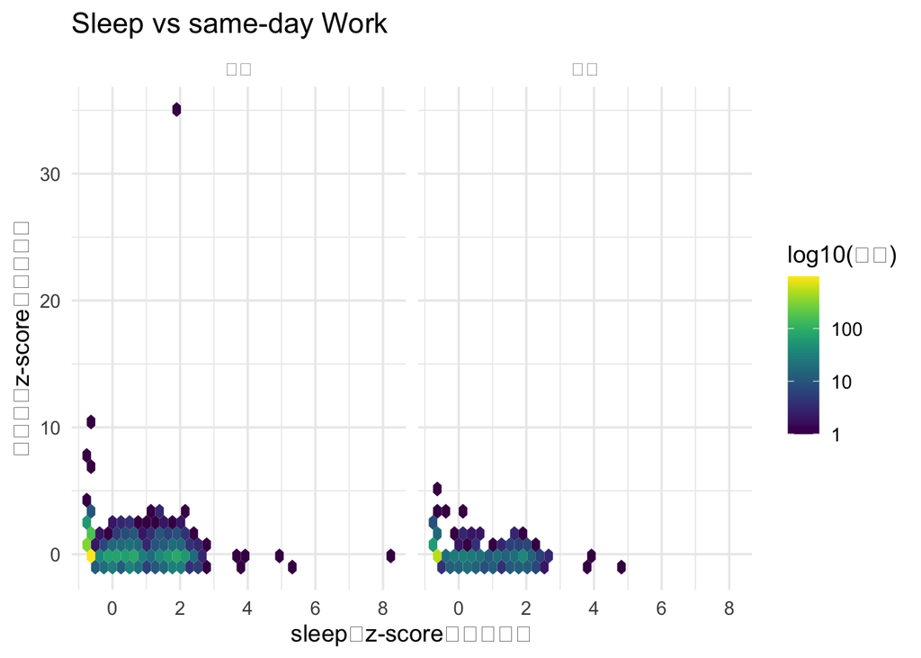

Figure 5. Sleep vs same-day Work（分周中/周末两列）。横轴：sleep（z-score，归一化）。纵轴：Work（z-score，归一化）。颜色：hexbin 密度（log10 计数）。

```r
y <- "work_z"
mod <- lm(as.formula(paste0(y, " ~ sleep_z * week_part")), data = daily)
print(plot_hex_facet(daily, y, "Sleep vs same-day Work"))
```

```r
kable(anova_table_with_eta(mod), digits = 3, caption = "ANOVA（F）与 partial η²：same-day Work")
```

ANOVA（F）与 partial η²：same-day Work

| term | df1 | df2 | F | p | eta_p2 | p_fmt | F_fmt | eta_fmt |
| --- | --- | --- | --- | --- | --- | --- | --- | --- |
| sleep_z | 1 | 3696 | 27.094 | 0.000 | 0.007 | 2.04e-07*** | F(1,3696)=27.09 | ηp²=0.007 |
| week_part | 1 | 3696 | 107.850 | 0.000 | 0.028 | 6.36e-25*** | F(1,3696)=107.85 | ηp²=0.028 |
| sleep_z:week_part | 1 | 3696 | 3.329 | 0.068 | 0.001 | 0.068 | F(1,3696)=3.33 | ηp²=0.001 |

```r
kable(tidy_star(mod), digits = 3,
      caption = paste0("回归系数（含方向）：", y, " ~ sleep_z * week_part"))
```

回归系数（含方向）：work_z ~ sleep_z * week_part

| term | estimate | std.error | statistic | p.value | sig | direction |
| --- | --- | --- | --- | --- | --- | --- |
| (Intercept) | 0.106 | 0.019 | 5.555 | 0.000 | *** |  |
| sleep_z | -0.104 | 0.019 | -5.477 | 0.000 | *** | 负向 |
| week_part周末 | -0.371 | 0.036 | -10.366 | 0.000 | *** | 负向 |
| sleep_z:week_part周末 | 0.066 | 0.036 | 1.824 | 0.068 |  | 正向 |

```r
kable(simple_slopes_binary(mod, xname = "sleep_z", by = "week_part"), digits = 3,
      caption = paste0("简单斜率（按周中/周末）：sleep_z → ", y))
```

简单斜率（按周中/周末）：sleep_z → work_z

| group | slope | std.error | statistic | p.value | sig | direction |
| --- | --- | --- | --- | --- | --- | --- |
| 周中 | -0.104 | 0.019 | -5.477 | 0.000 | *** | 更多→更低 |
| 周末 | -0.038 | 0.031 | -1.256 | 0.209 |  | 更多→更低 |

```r
kable(slope_diff_binary(mod, xname = "sleep_z", by = "week_part"), digits = 3,
      caption = paste0("斜率差（周末-周中）：sleep_z → ", y))
```

斜率差（周末-周中）：sleep_z → work_z

| contrast | slope_diff | std.error | statistic | p.value | sig | direction |
| --- | --- | --- | --- | --- | --- | --- |
| 周末 - 周中 | 0.066 | 0.036 | 1.824 | 0.068 |  | 周末斜率更大 |

```r
cat_slope_summary(mod, xname = "sleep_z", yname = y, by = "week_part")
```

```
##
## - **方向（简单斜率）**：在 week_part=周中 时，sleep_z↑ → work_z 更低（斜率=-0.104, p=4.61e-08）；在 week_part=周末 时，sleep_z↑ → work_z 更低（斜率=-0.0384, p=0.209）。
```

## 3.3 2.3 Same-day Mind_Clearing

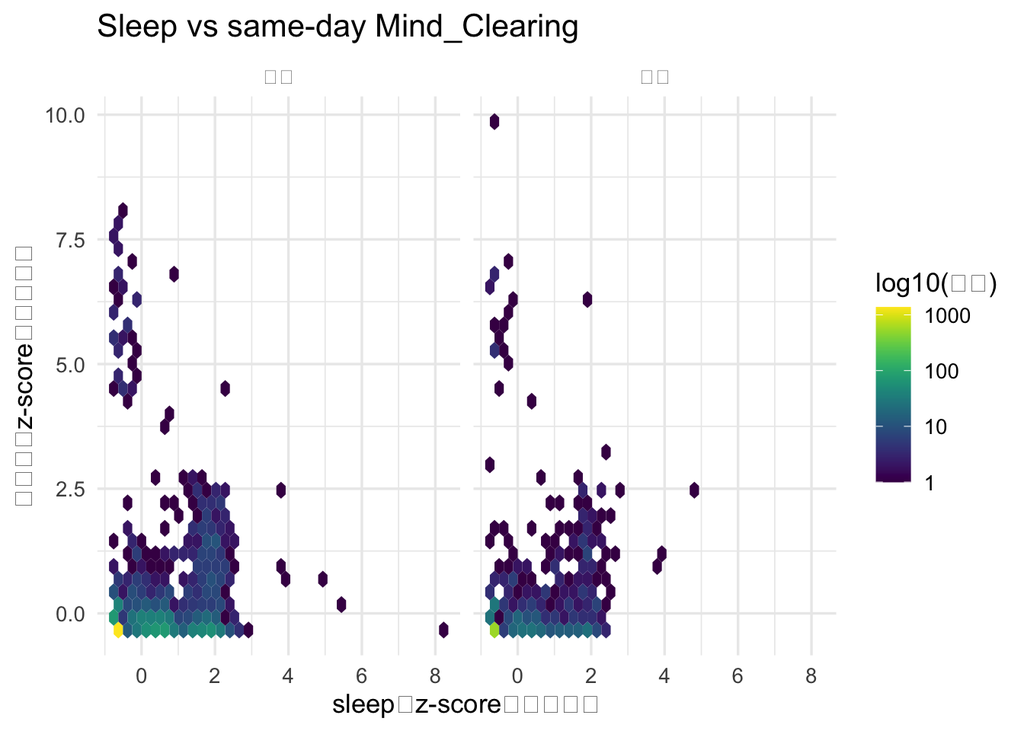

Figure 6. Sleep vs same-day Mind_Clearing（分周中/周末两列）。横轴：sleep（z-score，归一化）。纵轴：Mind_Clearing（z-score，归一化）。颜色：hexbin 密度（log10 计数）。

```r
y <- "mind_z"
mod <- lm(as.formula(paste0(y, " ~ sleep_z * week_part")), data = daily)
print(plot_hex_facet(daily, y, "Sleep vs same-day Mind_Clearing"))
```

```r
kable(anova_table_with_eta(mod), digits = 3, caption = "ANOVA（F）与 partial η²：same-day Mind_Clearing")
```

ANOVA（F）与 partial η²：same-day Mind_Clearing

| term | df1 | df2 | F | p | eta_p2 | p_fmt | F_fmt | eta_fmt |
| --- | --- | --- | --- | --- | --- | --- | --- | --- |
| sleep_z | 1 | 3696 | 181.544 | 0.000 | 0.047 | 1.98e-40*** | F(1,3696)=181.54 | ηp²=0.047 |
| week_part | 1 | 3696 | 1.061 | 0.303 | 0.000 | 0.303 | F(1,3696)=1.06 | ηp²=0.000 |
| sleep_z:week_part | 1 | 3696 | 1.338 | 0.247 | 0.000 | 0.247 | F(1,3696)=1.34 | ηp²=0.000 |

```r
kable(tidy_star(mod), digits = 3,
      caption = paste0("回归系数（含方向）：", y, " ~ sleep_z * week_part"))
```

回归系数（含方向）：mind_z ~ sleep_z * week_part

| term | estimate | std.error | statistic | p.value | sig | direction |
| --- | --- | --- | --- | --- | --- | --- |
| (Intercept) | -0.010 | 0.019 | -0.546 | 0.585 |  |  |
| sleep_z | 0.205 | 0.019 | 10.842 | 0.000 | *** | 正向 |
| week_part周末 | 0.037 | 0.036 | 1.042 | 0.298 |  | 正向 |
| sleep_z:week_part周末 | 0.041 | 0.036 | 1.157 | 0.247 |  | 正向 |

```r
kable(simple_slopes_binary(mod, xname = "sleep_z", by = "week_part"), digits = 3,
      caption = paste0("简单斜率（按周中/周末）：sleep_z → ", y))
```

简单斜率（按周中/周末）：sleep_z → mind_z

| group | slope | std.error | statistic | p.value | sig | direction |
| --- | --- | --- | --- | --- | --- | --- |
| 周中 | 0.205 | 0.019 | 10.842 | 0 | *** | 更多→更高 |
| 周末 | 0.246 | 0.030 | 8.100 | 0 | *** | 更多→更高 |

```r
kable(slope_diff_binary(mod, xname = "sleep_z", by = "week_part"), digits = 3,
      caption = paste0("斜率差（周末-周中）：sleep_z → ", y))
```

斜率差（周末-周中）：sleep_z → mind_z

| contrast | slope_diff | std.error | statistic | p.value | sig | direction |
| --- | --- | --- | --- | --- | --- | --- |
| 周末 - 周中 | 0.041 | 0.036 | 1.157 | 0.247 |  | 周末斜率更大 |

```r
cat_slope_summary(mod, xname = "sleep_z", yname = y, by = "week_part")
```

```
##
## - **方向（简单斜率）**：在 week_part=周中 时，sleep_z↑ → mind_z 更高（斜率=0.205, p=5.54e-27）；在 week_part=周末 时，sleep_z↑ → mind_z 更高（斜率=0.246, p=7.38e-16）。
```

# 4 3. Gaming / Cartoon：既做“受睡眠影响的因变量”，也做“影响学习/工作的自变量”

## 4.1 3.1 睡眠 → Gaming / Cartoon（分周中/周末）

## 4.2 3.1 睡眠 → Gaming / Cartoon（分周中/周末）

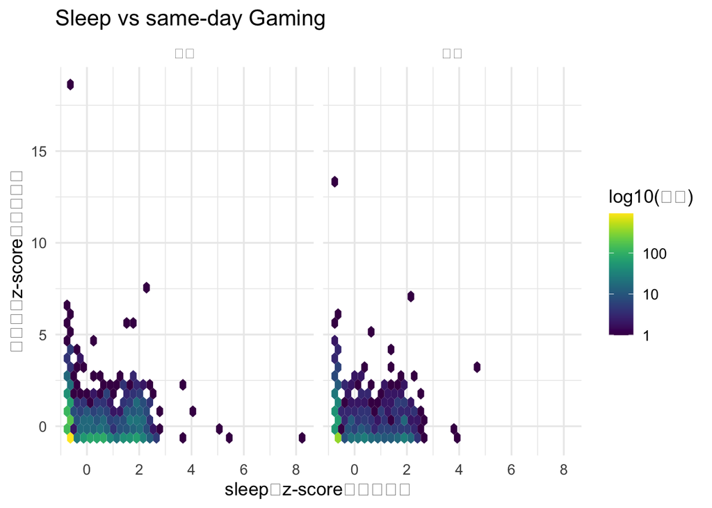

Figure 7. Sleep vs same-day Gaming（分周中/周末两列）。横轴：sleep（z-score，归一化）。纵轴：Gaming（z-score，归一化）。颜色：hexbin 密度（log10 计数）。

```
##
## - **方向（简单斜率）**：在 week_part=周中 时，sleep_z↑ → gaming_z 更高（斜率=0.0337, p=0.082）；在 week_part=周末 时，sleep_z↑ → gaming_z 更高（斜率=0.0437, p=0.160）。
```

```r
y <- "gaming_z"
if (y %in% names(daily)) {
  mod <- lm(as.formula(paste0(y, " ~ sleep_z * week_part")), data = daily)
  print(plot_hex_facet(daily, y, "Sleep vs same-day Gaming"))
  kable(anova_table_with_eta(mod), digits = 3, caption = "ANOVA（F）与 partial η²：same-day Gaming")

kable(tidy_star(mod), digits = 3,
      caption = paste0("回归系数（含方向）：", y, " ~ sleep_z * week_part"))
kable(simple_slopes_binary(mod, xname = "sleep_z", by = "week_part"), digits = 3,
      caption = paste0("简单斜率（按周中/周末）：sleep_z → ", y))
kable(slope_diff_binary(mod, xname = "sleep_z", by = "week_part"), digits = 3,
      caption = paste0("斜率差（周末-周中）：sleep_z → ", y))
cat_slope_summary(mod, xname = "sleep_z", yname = y, by = "week_part")

}
```

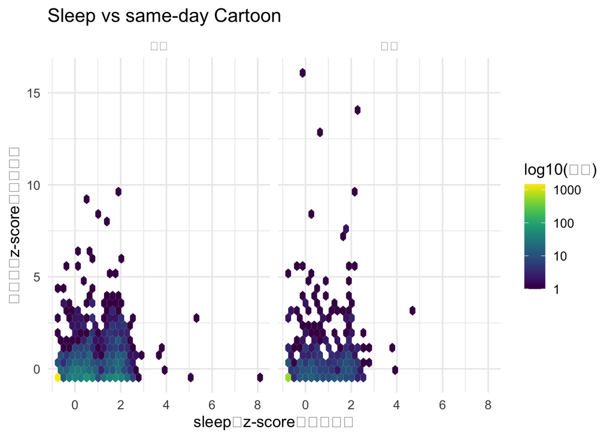

Figure 8. Sleep vs same-day Cartoon（分周中/周末两列）。横轴：sleep（z-score，归一化）。纵轴：Cartoon（z-score，归一化）。颜色：hexbin 密度（log10 计数）。

```
##
## - **方向（简单斜率）**：在 week_part=周中 时，sleep_z↑ → cartoon_z 更高（斜率=0.337, p=1.72e-75）；在 week_part=周末 时，sleep_z↑ → cartoon_z 更高（斜率=0.455, p=3.24e-54）。
```

```r
y <- "cartoon_z"
if (y %in% names(daily)) {
  mod <- lm(as.formula(paste0(y, " ~ sleep_z * week_part")), data = daily)
  print(plot_hex_facet(daily, y, "Sleep vs same-day Cartoon"))
  kable(anova_table_with_eta(mod), digits = 3, caption = "ANOVA（F）与 partial η²：same-day Cartoon")

kable(tidy_star(mod), digits = 3,
      caption = paste0("回归系数（含方向）：", y, " ~ sleep_z * week_part"))
kable(simple_slopes_binary(mod, xname = "sleep_z", by = "week_part"), digits = 3,
      caption = paste0("简单斜率（按周中/周末）：sleep_z → ", y))
kable(slope_diff_binary(mod, xname = "sleep_z", by = "week_part"), digits = 3,
      caption = paste0("斜率差（周末-周中）：sleep_z → ", y))
cat_slope_summary(mod, xname = "sleep_z", yname = y, by = "week_part")

}
```

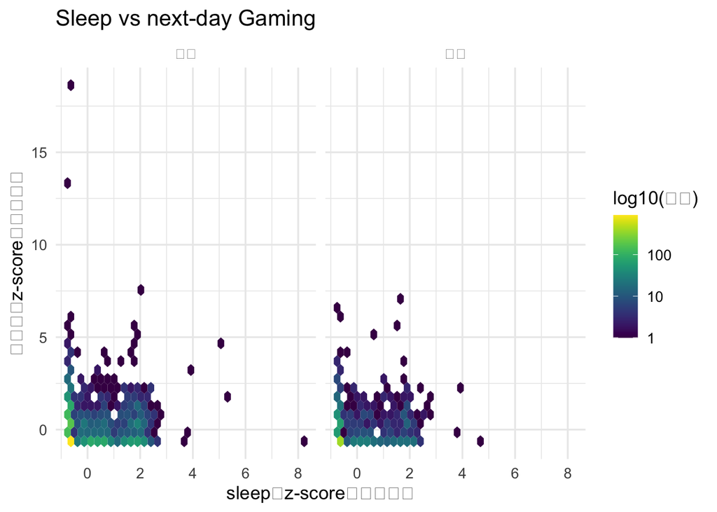

Figure 9. Sleep vs next-day Gaming（分周中/周末两列）。横轴：sleep（z-score，归一化）。纵轴：next-day Gaming（z-score，归一化）。颜色：hexbin 密度（log10 计数）。

```
##
## - **方向（简单斜率）**：在 week_part=周中 时，sleep_z↑ → gaming_next_z 更高（斜率=0.0432, p=0.025）；在 week_part=周末 时，sleep_z↑ → gaming_next_z 更高（斜率=0.104, p=8.01e-04）。
```

```r
y <- "gaming_next_z"
if (y %in% names(daily)) {
  mod <- lm(as.formula(paste0(y, " ~ sleep_z * week_part")), data = daily)
  print(plot_hex_facet(daily, y, "Sleep vs next-day Gaming"))
  kable(anova_table_with_eta(mod), digits = 3, caption = "ANOVA（F）与 partial η²：next-day Gaming")

kable(tidy_star(mod), digits = 3,
      caption = paste0("回归系数（含方向）：", y, " ~ sleep_z * week_part"))
kable(simple_slopes_binary(mod, xname = "sleep_z", by = "week_part"), digits = 3,
      caption = paste0("简单斜率（按周中/周末）：sleep_z → ", y))
kable(slope_diff_binary(mod, xname = "sleep_z", by = "week_part"), digits = 3,
      caption = paste0("斜率差（周末-周中）：sleep_z → ", y))
cat_slope_summary(mod, xname = "sleep_z", yname = y, by = "week_part")

}
```

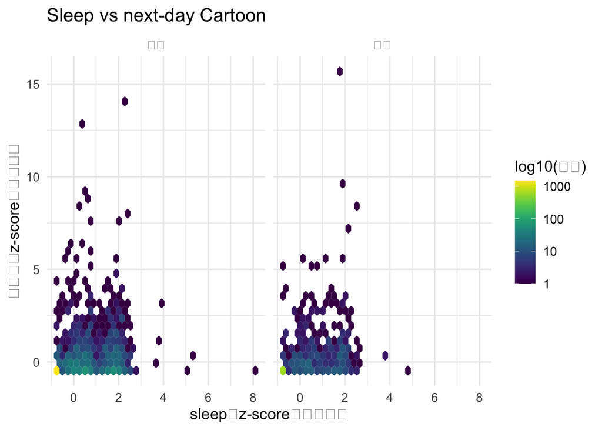

Figure 10. Sleep vs next-day Cartoon（分周中/周末两列）。横轴：sleep（z-score，归一化）。纵轴：next-day Cartoon（z-score，归一化）。颜色：hexbin 密度（log10 计数）。

```
##
## - **方向（简单斜率）**：在 week_part=周中 时，sleep_z↑ → cartoon_next_z 更高（斜率=0.337, p=6.33e-75）；在 week_part=周末 时，sleep_z↑ → cartoon_next_z 更高（斜率=0.438, p=3.32e-50）。
```

```r
y <- "cartoon_next_z"
if (y %in% names(daily)) {
  mod <- lm(as.formula(paste0(y, " ~ sleep_z * week_part")), data = daily)
  print(plot_hex_facet(daily, y, "Sleep vs next-day Cartoon"))
  kable(anova_table_with_eta(mod), digits = 3, caption = "ANOVA（F）与 partial η²：next-day Cartoon")

kable(tidy_star(mod), digits = 3,
      caption = paste0("回归系数（含方向）：", y, " ~ sleep_z * week_part"))
kable(simple_slopes_binary(mod, xname = "sleep_z", by = "week_part"), digits = 3,
      caption = paste0("简单斜率（按周中/周末）：sleep_z → ", y))
kable(slope_diff_binary(mod, xname = "sleep_z", by = "week_part"), digits = 3,
      caption = paste0("斜率差（周末-周中）：sleep_z → ", y))
cat_slope_summary(mod, xname = "sleep_z", yname = y, by = "week_part")

}
```

## 4.3 3.1R 反向：Gaming / Cartoon → 次日睡眠（分周中/周末）

同样把箭头反过来：如果某天 Gaming/Cartoon 较多，第二天的睡眠是否会出现统计差异？

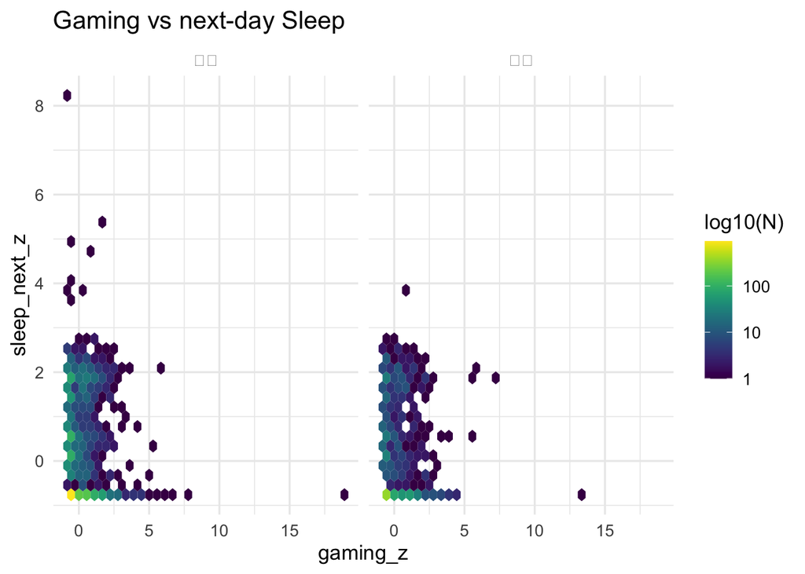

Figure. Gaming vs next-day Sleep（分周中/周末两列）。横轴：Gaming（z-score，归一化）。纵轴：next-day Sleep（z-score，归一化）。颜色：hexbin 密度（log10 计数）。

```
##
## - **方向（简单斜率）**：在 week_part=周中 时，gaming_z↑ → sleep_next_z 更高（斜率=0.0408, p=0.045）；在 week_part=周末 时，gaming_z↑ → sleep_next_z 更高（斜率=0.0452, p=0.107）。
```

```r
x <- "gaming_z"
y <- "sleep_next_z"
if (all(c(x, y) %in% names(daily))) {
  mod <- lm(as.formula(paste0(y, " ~ ", x, " * week_part")), data = daily)
  print(plot_hex_facet_xy(daily, x, y, "Gaming vs next-day Sleep"))
  kable(anova_table_with_eta(mod), digits = 3, caption = "ANOVA（F）与 partial η²：Gaming → next-day Sleep")
  kable(pred_table_3points_xy(mod, x), digits = 3, caption = "模型预测均值（示意：Gaming=-1/0/+1 SD）")

kable(tidy_star(mod), digits = 3,
      caption = paste0("回归系数（含方向）：", x, " → ", y))
kable(simple_slopes_binary(mod, xname = x, by = "week_part"), digits = 3,
      caption = paste0("简单斜率（按周中/周末）：", x, " → ", y))
kable(slope_diff_binary(mod, xname = x, by = "week_part"), digits = 3,
      caption = paste0("斜率差（周末-周中）：", x, " → ", y))
cat_slope_summary(mod, xname = x, yname = y, by = "week_part")

}
```

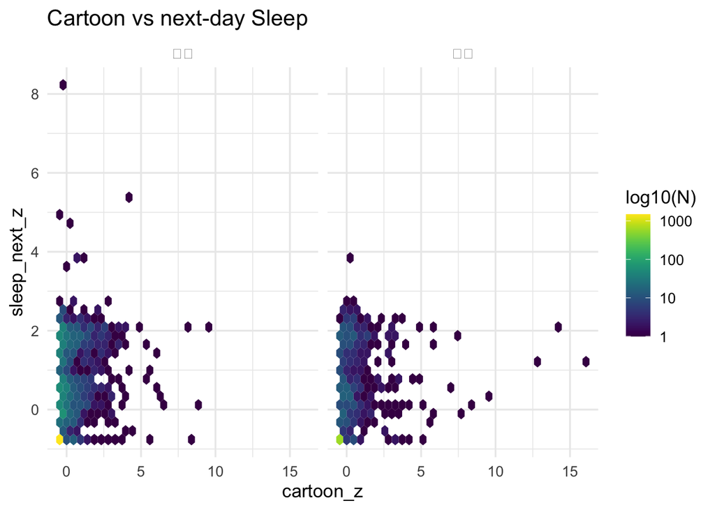

Figure. Cartoon vs next-day Sleep（分周中/周末两列）。横轴：Cartoon（z-score，归一化）。纵轴：next-day Sleep（z-score，归一化）。颜色：hexbin 密度（log10 计数）。

```
##
## - **方向（简单斜率）**：在 week_part=周中 时，cartoon_z↑ → sleep_next_z 更高（斜率=0.459, p=1.10e-97）；在 week_part=周末 时，cartoon_z↑ → sleep_next_z 更高（斜率=0.253, p=6.23e-30）。
```

```r
x <- "cartoon_z"
y <- "sleep_next_z"
if (all(c(x, y) %in% names(daily))) {
  mod <- lm(as.formula(paste0(y, " ~ ", x, " * week_part")), data = daily)
  print(plot_hex_facet_xy(daily, x, y, "Cartoon vs next-day Sleep"))
  kable(anova_table_with_eta(mod), digits = 3, caption = "ANOVA（F）与 partial η²：Cartoon → next-day Sleep")
  kable(pred_table_3points_xy(mod, x), digits = 3, caption = "模型预测均值（示意：Cartoon=-1/0/+1 SD）")

kable(tidy_star(mod), digits = 3,
      caption = paste0("回归系数（含方向）：", x, " → ", y))
kable(simple_slopes_binary(mod, xname = x, by = "week_part"), digits = 3,
      caption = paste0("简单斜率（按周中/周末）：", x, " → ", y))
kable(slope_diff_binary(mod, xname = x, by = "week_part"), digits = 3,
      caption = paste0("斜率差（周末-周中）：", x, " → ", y))
cat_slope_summary(mod, xname = x, yname = y, by = "week_part")

}
```